# Analyse de l’évolution de l’intérêt porté à la politique par les jeunes de 15 à 24 ans et des moins jeunes de 55 à 64 ans pour les élections européennes de 2019 et 2024.

Christ, Shnide, Jules

# 1 **Introduction**

« La démocratie ne peut vivre que si chacun y participe pleinement » - John Dewey. Pourtant, l’engagement politique varie considérablement selon les générations et les périodes. Si les jeunes de 15 à 24 ans représentent souvent une tranche d’âge en quête de repères politiques et d’idéaux à défendre, les moins jeunes, âgés de 55 à 64 ans, témoignent généralement d’un intérêt plus ancré et d’une participation plus régulière, façonnés par leur parcours de vie et les transformations sociopolitiques. Dans un contexte de baisse globale de la participation électorale, notamment pour les élections européennes, il est essentiel de s’interroger sur l’évolution de cet intérêt entre ces deux groupes d’âge. Quels sont les facteurs sociaux économiques qui influencent ces dynamiques générationnelles? Cette analyse se propose d’examiner les différences et les similitudes d’intérêt pour la politique chez les jeunes et les moins jeunes, en mettant en perspective les élections européennes de 2019 et celles de 2024.

Pour faire cela, nous allons filtré notre base de données en gardant le nom de la commune, son code postal, les inscrits, les votants et les abstentions pour le tour 1 des européennes de 2019.

# 2 **Etude pour les élections de 2019**

Tableau des proportions d’abstentions et de votants/ inscrits par commune pour les européennes de 2019 :

| Libellé de la commune | prop_Abs/Ins | prop_Vot/Ins | prop_15/24 | prop_55/64 |
| --- | --- | --- | --- | --- |
| Abilly | 45.6 | 54.4 | 13.6 | 31.3 |
| Ambillou | 47.4 | 52.6 | 16.5 | 21.0 |
| Amboise | 47.9 | 52.1 | 19.5 | 20.9 |
| Anché | 34.0 | 66.0 | 15.0 | 22.4 |
| Antogny Le Tillac | 45.6 | 54.4 | 16.1 | 23.6 |
| Artannes-Sur-Indre | 46.4 | 53.6 | 14.0 | 25.5 |
| Assay | 32.4 | 67.6 | 9.0 | 33.7 |
| Athée-Sur-Cher | 48.9 | 51.1 | 16.5 | 19.7 |
| Autrèche | 52.8 | 47.2 | 11.4 | 18.7 |
| Auzouer-En-Touraine | 46.2 | 53.8 | 16.5 | 19.4 |

Réalisation d’un tableau qui compare l’intérêt des 15/24 ans et des 55/64 ans pour le 1er tour des européennes de 2019 :

| Proportions | Les 15/24ans Tours | Les 15/24ans La Riche | Les 15/24ans Chambray-Lès-Tours | Les 55/64ans Chanceaux-Près-Loches | Les 55/64ans Brizay | Les 55/64ans Villedômain |
| --- | --- | --- | --- | --- | --- | --- |
| Abs/Ins | 51.8 | 50.8 | 46.7 | 33.6 | 38.4 | 30.2 |
| Vot/Ins | 48.2 | 49.2 | 53.3 | 66.4 | 61.6 | 69.8 |

Dans le but de comparer l’intérêt porté par ces deux tranches d’âge pour la politique, nous allons rassembler pour les éléctions européennes de 2024 les mêmes données pour ces 6 villes.

# 3 **Etude pour les élections de 2024**

On réalise un tableau de l’implication dans la vie politique des 15/24 et 55/64 pour les européennes de 2024 :

| Proportions | Les 15/24ans Tours | Les 15/24ans La Riche | Les 15/24ans Chambray-Lès-Tours | Les 55/64ans Chanceaux-Près-Loches | Les 55/64ans Brizay | Les 55/64ans Villedômain |
| --- | --- | --- | --- | --- | --- | --- |
| Abstention | 49.4 | 47.9 | 46.2 | 35.8 | 44.3 | 41.3 |
| Votant | 50.6 | 52.1 | 53.8 | 64.2 | 55.7 | 58.7 |

Comme pour le 1er tour des européennes de 2019, les plus jeunes **votent moins que les 55/64 ans**. Néanmoins, il serait pertinent d’observer si en moyenne les jeunes se sentent plus concernés qu’auparavant et si les moins jeunes répondent toujours autant présent lors d’échéances politiques. C’est dans ce but que l’on va réaliser un diagramme en bâtons qui mettra en perspective la variation du taux d’abstention des élections européennes de 2019 et 2024 pour les classes d’âges étudiées.

# 4 **Evolution de la participation électorale entre 2019 et 2024**

On va alors combiner nos deux tableaux en ne gardant que les proportions d’abstentions.

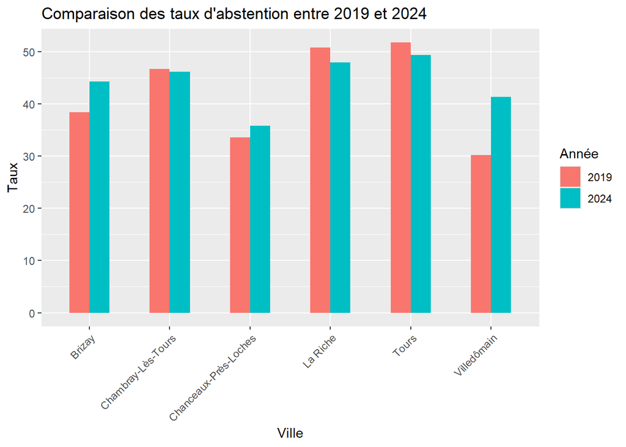

Si pour Brizay, Chanceaux-Près-Loches et Villedômain, **l’abstention a augmenté**, ce n’est pas le cas pour Tours, Chambray et La Riche. En d’autres termes, les villes avec le plus de 15/24 ans ont observé **une baisse de l’abstention** à l’inverse des villes où les 55/64 ans sont majoritaires. On peut encore vérifier les résultats attendus avec un test du Chi-deux.

# 5 **Test de significativité des proportions d’abstentions et de votants entre les 2 tranches d’âges**

**H0 nulle** : Les proportions de votants et d’abstentionnistes sont identiques entre les deux groupes d’âge. **H1 alternative** : Les proportions de votants et d’abstentionnistes diffèrent entre les deux groupes d’âge.

Tableau récapitulatif des résultats du test Chi-deux

|  | Statistique Chi-deux | Degrés de liberté | Valeur p |
| --- | --- | --- | --- |
| X-squared | 3.01 | 1 | 0.083 |

**Conclusion**:

La p-value est > 0.05, soit on conserve H0. Il n’y a pas de differences significatives de proportions de votants et d’abstentionnisme entre les deux groupes d’âges.

On pourrait alors se demander pourquoi les jeunes ont tendances à plus participer à la vie politique qu’il y a 5 ans. Et à l’inverse, pourquoi les plus âgés se désintéressent de celle-ci ? Pour tenter de répondre à cette question, intéressons nous, dans un premier temps, à ce que ces classes d’âge ont voté.

# 6 **Détail des votes pour les européennes de 2019**

Pour mener l’étude, on supposera d’abord que le vote des villes avec une majorité de jeunes ou de plus âgés représentent, de manière générale, le vote des ces classes d’âges. On continuera ainsi nos recherches avec les villes de Tours, Chambray, La Riche, Villedômain, Chanceaux-Près-Loches et Brizay.

On récupère alors les données sur le vote de ces villes pour 2019 :

Répartition des votes pour le 1er tour des européennes de 2019 :

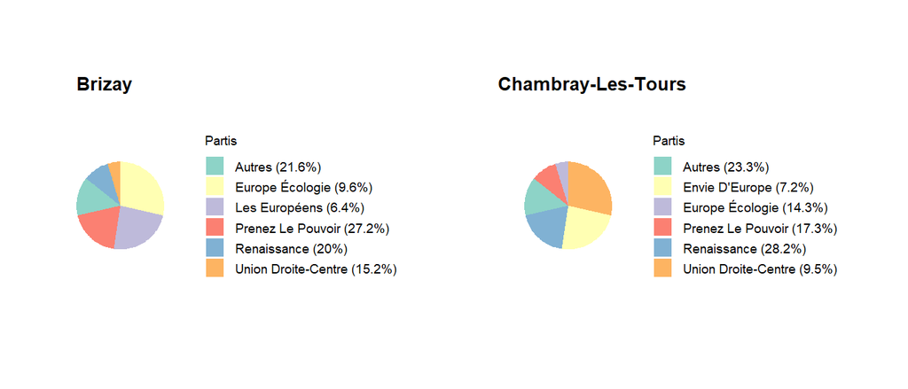

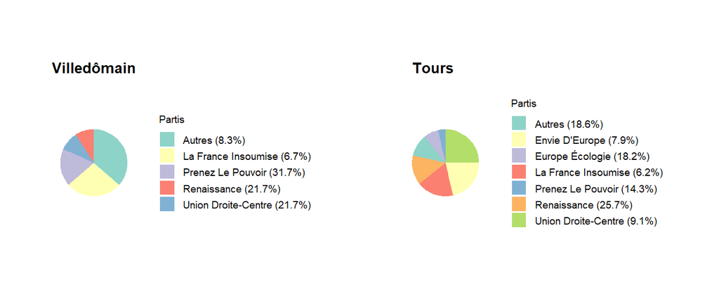

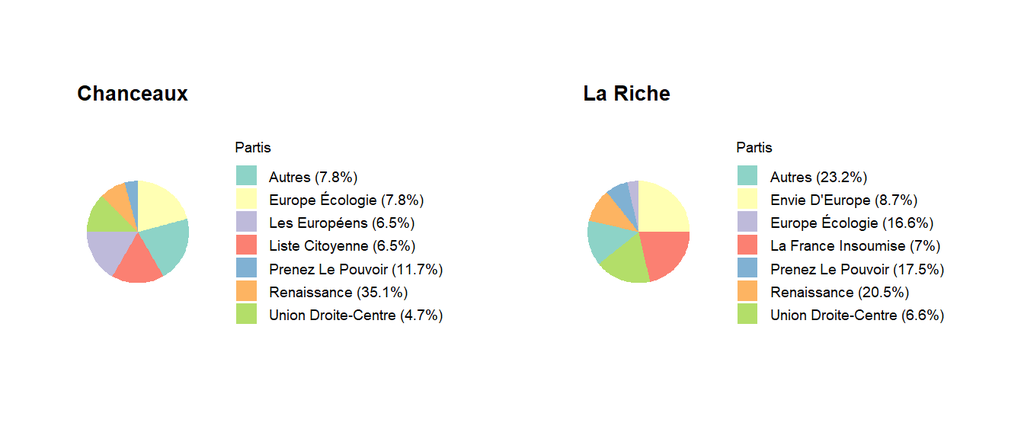

On peut traduire de ces résultats un **fort espoir**, indépendamment des tranches d’âges, **placé en E.Macron et son parti** fraîchement élu à la présidence de la République 2 ans auparavant. De plus, la liste soutenue par M.Lepen est considérablement présente. On observe néamoins qu’elle est **bien moins soutenue** dans les villes où les jeunes sont le plus présent.

On peut également constater que le vote écologiste est grandement présent à l’inverse des autres villes. On peut peut-être en déduire un attachement plus fort des jeunes générations à la cause environnmentale.

# 7 **Etude pour les élections de 2024**

Afin de mettre ces résultats en perspective, il serait pertinent de les confronter à ceux de 2024. Nous constaterons si la confiance accordée à E.Macron a été redonnée. Est ce que le vote M.Lepen s’est accru ? Quid du vote écologistes ?

Répartition des voix pour les européennes de 2024 :

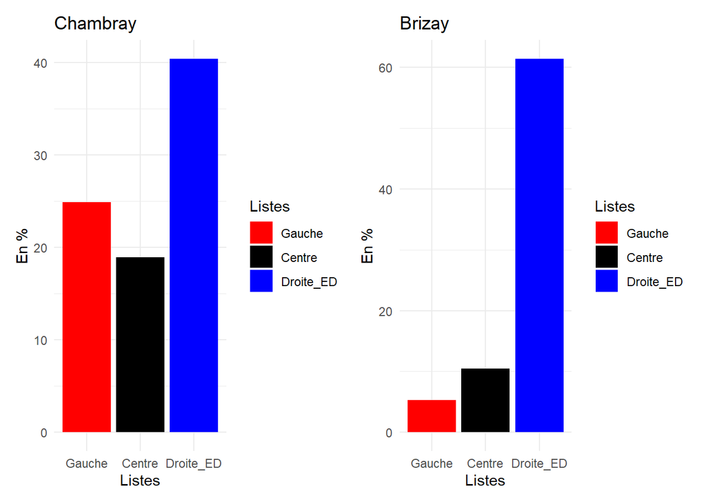

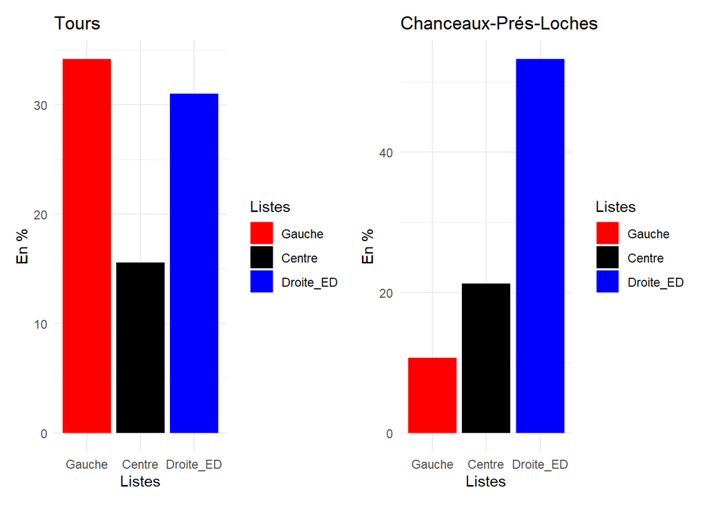

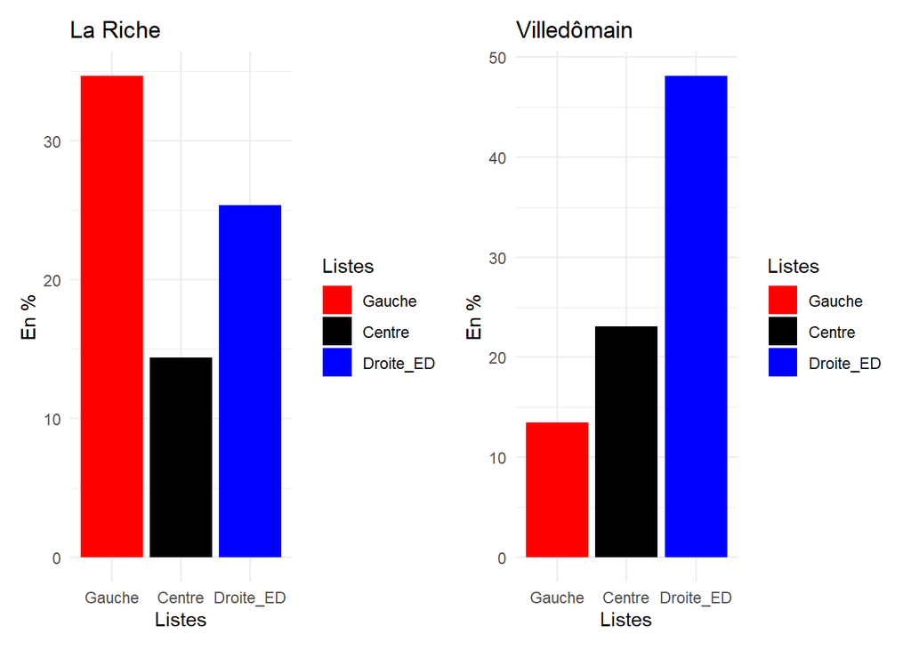

Globalement, l’adhesion au bloc macroniste semble **s’être affaiblie en 5 ans** indépendamment de l’âge de la population.

A l’exception de Chambray-Les-Tours, où le vote à droite voire extrême droite s’est **considérablement renforcé**, il est resté plutôt stable pour Tours et La Riche. Concernant les villes plus âgées, on remarque une **forte hausse du vote à droite** (sauf pour Villedômain où il est rester stable).

Après avoir été quasi-inexistant en 2019, **l’adhésion aux partis de gauche est hautement marquée dans les villes dites plus jeunes** atteignant environ 35% à Tours et à La Riche. Malgrè un faible pourcentage, il est tout de même présent chez les 55/64 ans là où il était presque invisble en 2019.

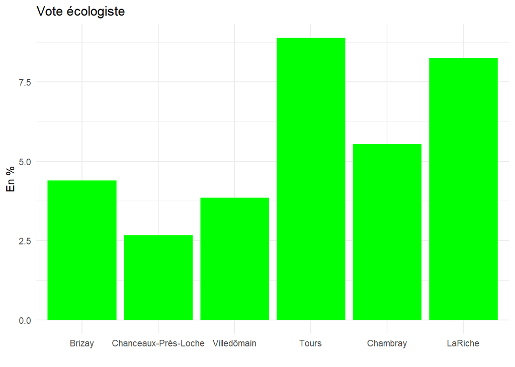

Pour ce qui est du vote écologiste, la tendance se confirme : Les verts **recueillent plus de voix dans les villes où la population est âgée entre 15/24 ans.**

Mais à quel point ces résultats sont-ils **fiablent** ? Comportent-ils des **biais** ? Si oui, quels facteurs omis influencent les résultats ? Déjà rappelons que nous ne pouvons qu’entrevoir des tendances qui se dégageraient de ces élections. Une ville où les 55/64 ans sont le plus représentés **n’explique pas à 100%** les résultats de cette ville. Enfin, on pourrait résonner non plus en fonction de l’âge mais en fonction du **statut social** dans la société. Soit réflechir aux votes des étudiants, des actifs, des chômeurs, des retraités/pré-retraités, ect. Est ce qu’un actif de 23 ans ne voterait-il pas la même chose que celui de 55 ans ?

Pour tenter d’y voir plus clair, nous procèderons de la manière suivante : nous allons tirer, du département d’Indre et Loire, la ville avec le + de : **d’étudiants** **de chômeurs** **d’actifs occupés** **retraités**

Nous considérerons, comme précédemment, que le vote de ces villes représenterait le vote de chaque classe sociale.

| Statut_social | Gauche _ La France Insoumise | Gauche _ Envie D’Europe | Gauche _ Liste Citoyenne | Gauche _ Pour L’Europe Des Gens | Centre _ Renaissance | Droite et extrême-droite _ Debout La France | Droite et extrême-droite _ Union Droite-Centre | Droite et extrême-droite _ Prenez Le Pouvoir |
| --- | --- | --- | --- | --- | --- | --- | --- | --- |
| Actifs occupés | 6.9 | 7.4 | 4.2 | 2.7 | 19.9 | 7.2 | 8.5 | 21.5 |
| Retraités | 7.8 | 10.3 | 3.5 | 3.8 | 23.8 | 5.9 | 8.4 | 19.2 |
| Chômeurs | 10.0 | 7.1 | 5.3 | 9.1 | 13.9 | 2.6 | 3.5 | 19.2 |
| Etudiants | 6.2 | 7.9 | 4.0 | 2.1 | 25.7 | 2.5 | 9.1 | 14.3 |

Vote en fonction du statut social : Données de 2019.

| Statut_social | Gauche _ Lfi - Up-LFI | Gauche _ Lutte Ouvriere-LEXG | Gauche _ Reveil Eur-LUG | Gauche _ Gauche Unie-LCOM | Centre _ Besoin D’Europe-LENS | Droite et extrême-droite _ Reconquête | Droite et extrême-droite _ La France Revient-LRN | Droite et extrême-droite _ Républicains | Droite et extrême-droite _ Ar-LDVD |
| --- | --- | --- | --- | --- | --- | --- | --- | --- | --- |
| Actifs occupés | 6.5 | 1.1 | 12.0 | 4.0 | 12.8 | 4.4 | 41.0 | 6.3 | 0.8 |
| Retraités | 6.4 | 1.1 | 18.2 | 5.5 | 14.6 | 4.7 | 25.4 | 8.0 | 3.3 |
| Chômeurs | 22.9 | 1.1 | 16.6 | 7.3 | 9.5 | 3.3 | 20.5 | 2.6 | 0.8 |
| Etudiants | 14.7 | 0.5 | 19.5 | 1.9 | 15.6 | 5.2 | 17.9 | 7.9 | 1.0 |

Vote en fonction du statut social : Données de 2024.

**Etudiants :**

Globalement, les villes avec le plus d’étudiants **votaient E.Macron et à droite en 2019**. On remarque, en 2024, que le vote au centre **a chuté au profit de la gauche.** Le vote à droite est lui resté plus ou moins stable.

**Actifs occupés :**

En 2019, les résultats témoignent d’une **large victoire de la droite/ED** avec un soutient macroniste néanmoins. Le vote à gauche est **minoritaire**. En 2024, il a basculé **très lourdement en faveur de la droite/ED** avec près de **50%** contre environ 23% pour la gauche.

**Chômeurs :**

En 2019, on observe plutôt une **tendance à gauche** sans toutefois eclipser le vote Macron et Lepen. En 2024, il a **très fortement basculé à gauche** délaissant un peu plus le vote centriste.

**Retraités :**

Globalement, on constate, comme le montrait le vote/âge, une **perte de confiance en E.Macron** et son parti. Cela peut s’expliquer du simple fait qu’il était inconnu aux yeux du grand public et suscitait donc de l’espoir et des attentes. 5 ans plus tard, il ne semble pas avoir convaincu la population, peu importe son âge ou son statut social.

# 8 **Test de significativité**

# 9 **Conclusion**